```python
import matplotlib.pyplot as plt, numpy as np
```

# Non Linear Classificaion and Regression

# Feature Vector

### Example 1

If $x^{(t)}\in\mathbb{R} (t=1,2,3)$ ,

[figure not shown]

we can define a feature map $\phi(x)=[\phi_1(x),\phi_2(x)]^T$ where $\phi_1(x)=x$ and $\phi_2(x)=x^2$  
1-d space (x) -> 2-d space ($\phi_1,\phi_2$)

[figure not shown]

In this case, our feature vector is $\phi(x^{(t)})=[x^{(t)},(x^{(t)})^2]^T$

### Example 2

If $x=[x_{1}^{(t)},x_{2}^{(t)}]\in \mathbb{R}^2$ ,

[figure not shown]

Since the possible boundry is an eclipse, according to its equation, we have  
$\theta_1x_1+\theta_2x_2+\theta_3x_1x_2+\theta_4x_1^2+\theta_5x_2^2+\theta_0=\theta\cdot[x_1,x_2,x_1x_2,x_1^2,x_2^2]^T+\theta_0=0 $  
$\because \theta\cdot\phi(x)+\theta_0=0$  
$\therefore \phi(x)=[x_1,x_2,x_1x_2,x_1^2,x_2^2]^T$

#### Non Linear Classification

$$h(x;\theta,\theta_{0})=sign(\theta\cdot\phi(x)+\theta_0)$$

#### Non Linear Regression

$$f(x;\theta,\theta_{0})=\theta\cdot\phi(x)+\theta_0$$

### Why not feature vectors?

It brings empressive power but also high dimensions.

[figure not shown]

Let $x\in\mathbb{R}^{150}$, i.e. $x=[x_1,x_2,...,x_{150}]^T$ and $\phi(x)$ be an order 3 polynomial feature vector,  
then $\phi(x)=[{\color{red} {x_1, x_2,...,x_i ,...,x_{150}}},{\color{Blue}{{x_1}^2, x_1x_2, ...,x_ix_j,...,{x_{150}}^2}},{\color{Green} {{x_1}^3, {x_1}^2x_2, ...,x_ix_jx_k,...,{x_{150}}^3}}]$  
where ${\color{red}{deg1=\binom{150}{1}}}$ ${\color{blue}{deg2=\binom{150}{2}}}$ ${\color{green}{deg3=\binom{150}{3}}}$  
$\therefore $ $d = deg1+deg2+deg3=585275$  
Thus, we need regularization:  
Small $\lambda$

[figure not shown]

Large $\lambda$

[figure not shown]

# Kernel

Computing the inner product between two feature vectors can be cheap even if the vectors are very high dimensional. This type of dot function of two feature vectors/examples is a kernel function.

### Example 1

Assume we map $x$ and $x'∈ℝ^2$ to feature vectors 𝜙(𝑥) and 𝜙(𝑥′) given by  
$\phi(x)=[{\color{red} {x_1,x_2}},{\color{blue} {{x_1}^2,\sqrt{2}x_1x_2,{x_2}^2}}]$  
$\phi(x')=[{\color{red} {x_1',x_2'}},{\color{blue} {{x_1'}^2,\sqrt{2}x_1'x_2',{x_2'}^2}}]$  
$\therefore$ a kernel $K\left \langle x,x' \right \rangle=\phi(x) \cdot \phi(x')={\color{red} {(x\cdot x')}}+{\color{blue} {(x\cdot x')^2}}$

### Example 2

If $K\left \langle x,x' \right \rangle=\phi(x)\cdot\phi(x')={\color{red} {x_1x_1'}}+{\color{blue} {x_2x_2'+x_2x_3'+x_3x_2'+x_3x_3'}}$  
then $\phi(x)=[{\color{red} {x_1}},{\color{blue} {x_2+x_3}}]$ $\phi(x')=[{\color{red} {x_1'}},{\color{blue} {x_2'+x_3'}}]$

# Kernel Perceptron Algorithm

**Perceptron** $\left ( \left \{ (x^{(i)},y^{(i)}),i=1,...,n \right \} ,T\right ):$  
initialize $\theta=0, \theta_0=0$ (vector);  
for $𝑡=1,...,𝑇$ ,  
for $𝑖=1,...,𝑛$ ,  
if $y^{(i)}(\theta \cdot x^{(i)}+\theta_0)\leqslant 0$ ,  
then update $\theta=\theta+y^{(i)}\cdot x^{(i)}, \theta_0=\theta_0+y^{(i)} $

**Now** $\because \theta = \sum_{j=1}^{n} a_j y^{(j)} \phi(x^{(j)}), \therefore $ we can substitute  
initialize $\theta=0, \theta_0=0$ (vector);  
with  
initialize $a_1=...=a_n=0$ ;

**Kernel Perceptron** $\left ( \left \{ (x^{(i)},y^{(i)}),i=1,...,n \right \} ,T\right ):$  
initialize $a_1,...,a_n $ to some value ;  
for $𝑡=1,...,𝑇$ ,  
for $𝑖=1,...,𝑛$ ,  
if $y^{(i)}(\sum_{j=1}^{n} a_j y^{(j)} \phi(x^{(j)})\phi(x^{(i)})+\theta_0)\leqslant 0$ ,  
then update $a_i=a_i+i $

Here $K\left \langle x^{(j)},x^{(i)} \right \rangle=\phi(x^{(j)}) \cdot \phi(x^{(i)})$

```python
def perceptron(feature_matrix, labels, T):
    """
    Runs T iterations through a given set of data, there is no need to worry about stopping early.

    Args:
        feature_matrix - A numpy matrix describing the given data X.
        labels - A numpy array, correctly classified Y.
        T - An integer indicating how many times the perceptron algorithm should iterate through the feature matrix.

    Returns: A tuple of a numpy array with the value of theta and a real number with the value of theta_0
    """
    theta, theta_0, a = np.zeros(feature_matrix.shape[1]), 0, np.zeros(feature_matrix.shape[0])
    for t in range(T):
        for i in range(feature_matrix.shape[0]):
            res = sum([theta[j]*labels[j]*np.dot(kernal(feature_matrix[j]),kernal(feature_matrix[i]).T) for j in range(feature_matrix.shape[0])])
            if labels[i] * (res + theta_0) <= 0:
                a += i

                theta_0 += labels[i]
    return (theta, theta_0)
```

```python
def kernal(x):
    return np.array([x[0]^2,np.sqrt(2)*x[0]*x[1],x[1]^2])
```

### Composition rules:

1. $K\left \langle x,x' \right \rangle = 1$ is a kernel function.  
   $\therefore \phi(x)=1$
2. Let $f:\mathbb{R}^d \rightarrow \mathbb{R}$ , where $f(x)$ is a scalr, and $K\left \langle x,x' \right \rangle$ is a kernel. Then so is $\widetilde{K}\left \langle x,x' \right \rangle=f(x)K\left \langle x,x' \right \rangle f(x')$.  
   $\therefore \phi(x)=1 \cdot f(x)$ or say $ \varphi(x) = \phi(x) \cdot f(x)$
3. If $K_1\left \langle x,x' \right \rangle$ and $K_2\left \langle x,x' \right \rangle$ are kernels, then $K\left \langle x,x' \right \rangle = K_1\left \langle x,x' \right \rangle + K_2\left \langle x,x' \right \rangle$ is a kernel
4. If $K_1\left \langle x,x' \right \rangle$ and $K_2\left \langle x,x' \right \rangle$ are kernels, then $K\left \langle x,x' \right \rangle = K_1\left \langle x,x' \right \rangle K_2\left \langle x,x' \right \rangle$ is a kernel

### Example 1

If $f:\mathbb{R}^d \rightarrow \mathbb{R}$ and $K\left \langle x,x' \right \rangle$ is a kernel, so is $\widetilde{K}\left \langle x,x' \right \rangle=f(x)K\left \langle x,x' \right \rangle f(x')$.

If $K\left \langle x,x' \right \rangle=\phi(x) \cdot \phi(x')$ and $\widetilde{K}\left \langle x,x' \right \rangle=\varphi(x) \cdot \varphi(x')$ then $\varphi(x)=f(x)\phi(x)$

### Example 2

1. 1 is a kernel for $\phi(x)=1$
2. $x\cdot x'$ is a kernel for $\phi(x)=x$
3. $1+x \cdot x'$ is a kernel since the sum of kernels are still kernels for $\phi(x)=[1,x]^T$
4. $(1+x \cdot x')^2$ is a kernel since the product of kernels are kernels. (In this case, factoring the kernel as dot products are more involved, and the composition rule saves this work.)
5. $exp(x+x')$ is a kernel for $\phi(x)=exp(x)$
6. $min(x,x') $ for $ x, x' \in \mathbb{Z}$ is **NOT** a kernel.  
   For example, min(−1,−1)=−1<0 and hence cannot be written as a dot product and is not a valid kernel.

# Radial Basis Kernel

The feature vectors can be infinite dimensional... this means that they have unlimited expressive power.

Gaussian RBF Kernel: $K\left \langle x,x' \right \rangle = e^{-\frac{1}{2\sigma}\left \| x-x' \right \|^2}$

[figure not shown]

$\left \| x-x' \right \|^2=(x-x')^T(x-x')=x^Tx-x^Tx'-x'^Tx+x'^Tx'$

# Random Forest

Random forest is a good default classifier for (almost) any setting.

[figure not shown]

Procedure:

- boostrap sample
- build a (randomized) decision tree
- average predictions (ensemble)

# Summary

1. We can get non-linear classifiers or regression methods by simply mapping examples into feature vectors non-linearly, and applying a linear method on the resulting vectors
2. These feature vectors can be high dimensional, however
3. We can turn the linear methods into kernel methods by casting the computations in terms of inner products
4. A kernel function is simply an inner product between two feature vectors
5. Using kernels is advantageous when the inner products are faster to evaluate than using explicit vectors (e.g., when the vectors would be infinite dimensional!)

### Example

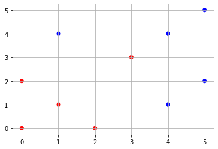

```python
X = [(0,0),(2,0),(1,1),(0,2),(3,3),(4,1),(5,2),(1,4),(4,4),(5,5)]
y = [ -1,   -1,   -1,   -1,   -1,   +1,   +1,   +1,   +1,   +1  ]
perceptron_mistakes = [1,65,11,31,72,30,0,21,4,15]

plt.scatter([i[0] for i in X],[i[1] for i in X],color=['r']*5+['b']*5)
plt.grid()
plt.show()
```

Kernal: $\phi(x)=[x_1^2,\quad \sqrt{2}x_1 x_2,\quad x_2^2]^T$

```python
perceptron(np.array(X), y, 10)
```

[output not shown]